# Balance and Sequentiality in Bayesian Analysis

## R Packages Needed

- To follow today’s lecture, please load the following packages:

```r
library(tidyverse)
library(bayesrules)
library(bayesplot)
library(ssstats)
library(ggpubr)
```

## Introduction

- Last week, we learned the conjugate families.
  - Beta-Binomial
  - Gamma-Poisson
  - Normal-Normal
- Today we will discuss balance and sequentiality in Bayesian analyses.

## Introduction: Example

- In Alison Bechdel’s 1985 comic strip The Rule, a character states that they only see a movie if it satisfies the following three rules (Bechdel 1986):
  - the movie has to have at least two women in it;
  - these two women talk to each other; and
  - they talk about something besides a man.
- Let $\pi$, a random value between 0 and 1, denote the unknown proportion of recent movies that pass the Bechdel test.

## Introduction: Example

- Three friends (feminist, clueless, and optimist) have some prior ideas about $\pi$.
  - Reflecting upon movies that he has seen in the past, the feminist understands that the majority lack strong women characters.
  - The clueless doesn’t really recall the movies they’ve seen, and so are unsure whether passing the Bechdel test is common or uncommon.
  - Lastly, the optimist thinks that the Bechdel test is a really low bar for the representation of women in film, and thus assumes almost all movies pass the test.
- Graph the following priors and determine which prior belongs to each friend:

```r
plot_beta(alpha = 1, beta = 1) + theme_minimal()
plot_beta(alpha = 5, beta = 11) + theme_minimal()
plot_beta(alpha = 14, beta = 1) + theme_minimal()
```

## Example

- The clueless doesn’t really recall the movies they’ve seen, and so are unsure whether passing the Bechdel test is common or uncommon.

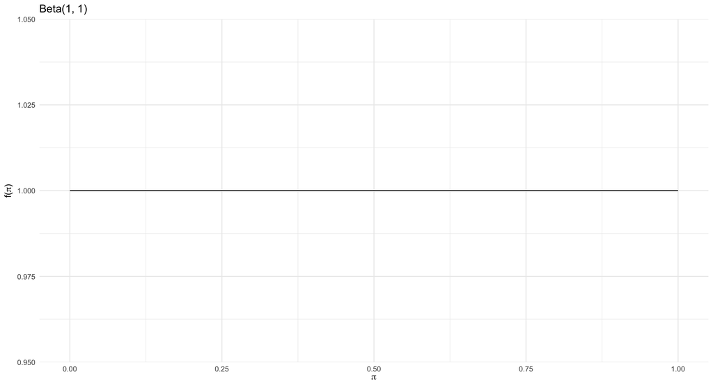

## Example

- Reflecting upon movies that he has seen in the past, the feminist understands that the majority lack strong women characters.

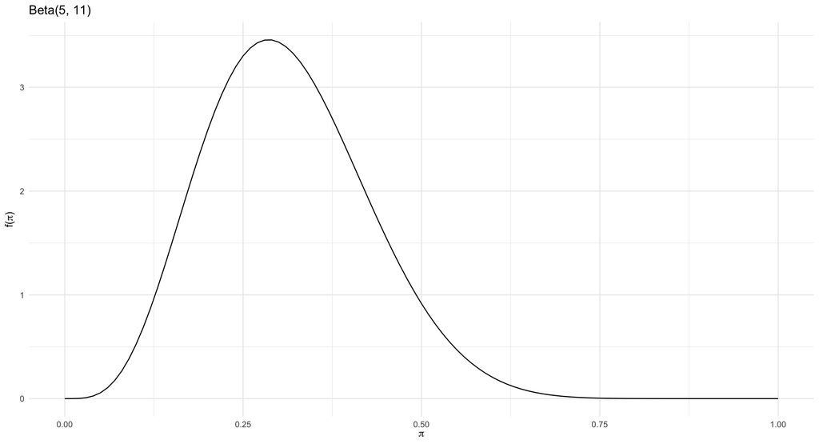

## Example

- Lastly, the optimist thinks that the Bechdel test is a really low bar for the representation of women in film, and thus assumes almost all movies pass the test.

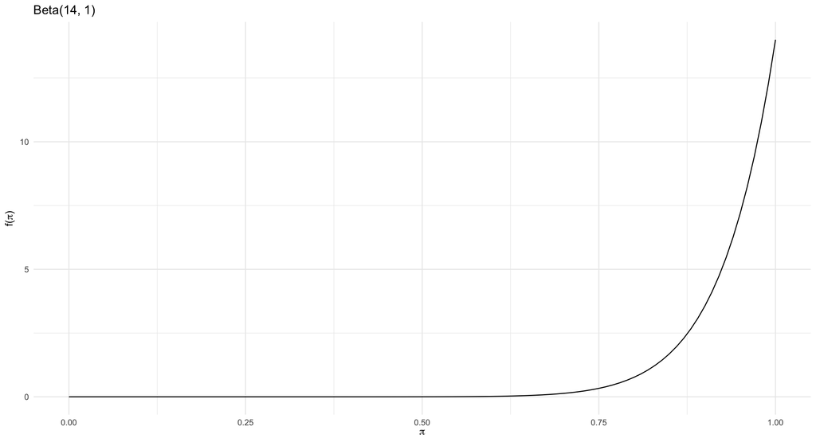

## Example

- The analysts agree to review a sample of $n$ recent movies and record $Y$, the number that pass the Bechdel test.
  - Because the outcome is yes/no, the binomial distribution is appropriate for the data distribution.
  - We aren’t sure what the population proportion, $\pi$, is, so we will not restrict it to a fixed value.
    - Because we know $\pi \in [0, 1]$, the beta distribution is appropriate for the prior distribution.

$$\begin{align*}
Y|\pi &\sim \text{Bin}(n, \pi) \\
\pi &\sim \text{Beta}(\alpha, \beta)
\end{align*}$$

## Example

- Because we know $\pi \in [0, 1]$, the beta distribution is appropriate for the prior distribution.

$$\begin{align*}
Y|\pi &\sim \text{Bin}(n, \pi) \\
\pi &\sim \text{Beta}(\alpha, \beta)
\end{align*}$$

- From the previous chapter, we know that this results in the following posterior distribution

$$\pi | (Y=y) \sim \text{Beta}(\alpha+y, \beta+n-y)$$

## Different Priors $\to$ Different Posteriors

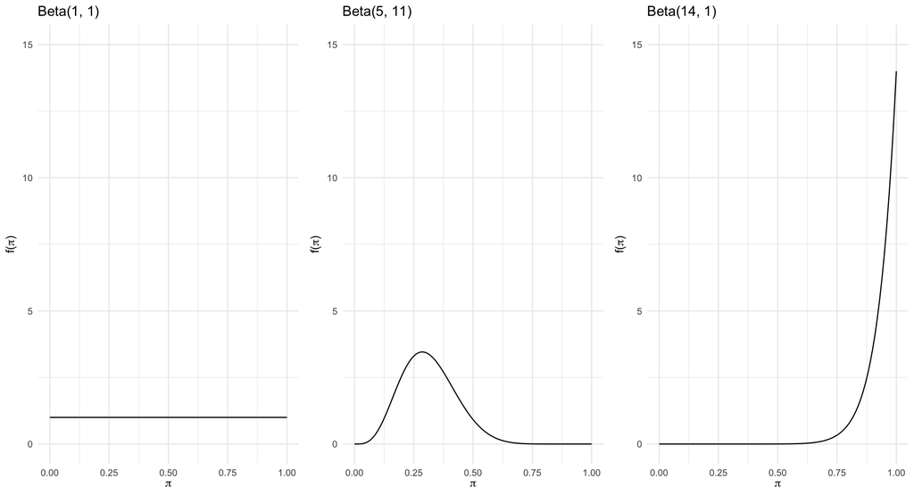

- The differing prior means show disagreement about whether $\pi$ is closer to 0 or 1.
- The differing levels of prior variability show that the analysts have different degrees of certainty in their prior information.

## Different Priors $\to$ Different Posteriors

- Okay, great! We have different priors.
  - How do the different priors affect the posterior?
- We have data from FiveThirtyEight, reporting results of the Bechdel test.

| year | title | binary |
| --- | --- | --- |
| 2013 | Her | FAIL |
| 1997 | Grosse Pointe Blank | PASS |
| 2006 | Volver | PASS |
| 1989 | UHF | FAIL |
| 2011 | Transformers: Dark of the Moon | PASS |

## Different Priors $\to$ Different Posteriors

- How many pass the test in this sample?

```r
bechdel20 %>% n_pct(binary)
```

| binary | n (pct) |
| --- | --- |
| FAIL | 11 (55.0%) |
| PASS | 9 (45.0%) |

- Find the posterior distributions. (i.e., What are the updated parameters?)

| Analyst | Prior | Posterior |
| --- | --- | --- |
| the feminist | Beta(5, 11) | Beta(?<sub>1</sub>, ?<sub>2</sub>) |
| the clueless | Beta(1, 1) | Beta(?<sub>1</sub>, ?<sub>2</sub>) |
| the optimist | Beta(14, 1) | Beta(?<sub>1</sub>, ?<sub>2</sub>) |

## Different Priors $\to$ Different Posteriors

- Find the posterior distributions. (i.e., What are the updated parameters?)

| Analyst | Prior | Posterior |
| --- | --- | --- |
| the feminist | Beta(5, 11) | Beta(14, 22) |
| the clueless | Beta(1, 1) | Beta(10, 12) |
| the optimist | Beta(14, 1) | Beta(23, 12) |

## Different Priors $\to$ Different Posteriors

- Let’s now explore what the posteriors look like.

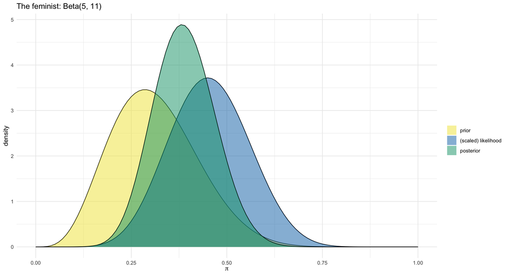

## Different Priors $\to$ Different Posteriors

- Let’s now explore what the posteriors look like.

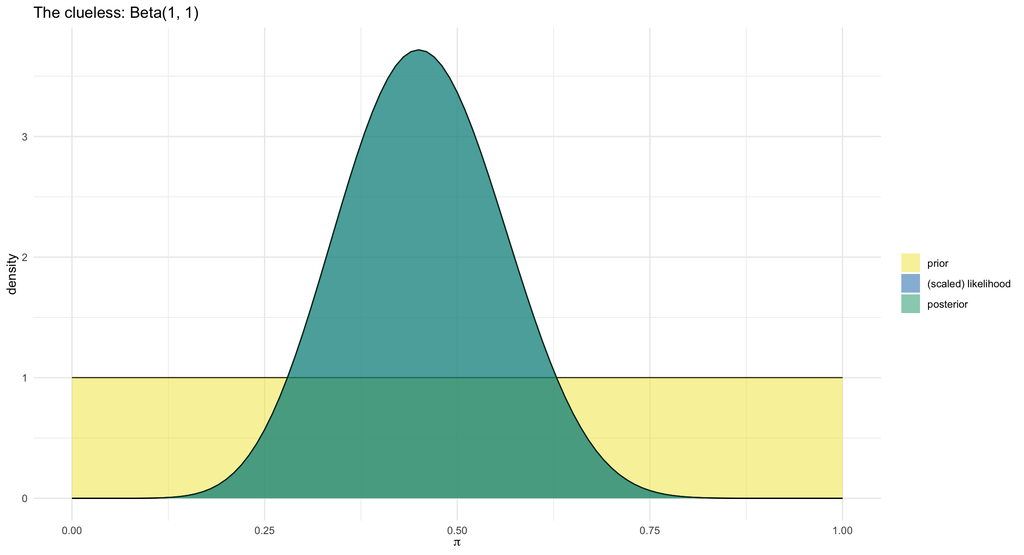

## Different Priors $\to$ Different Posteriors

- Let’s now explore what the posteriors look like.

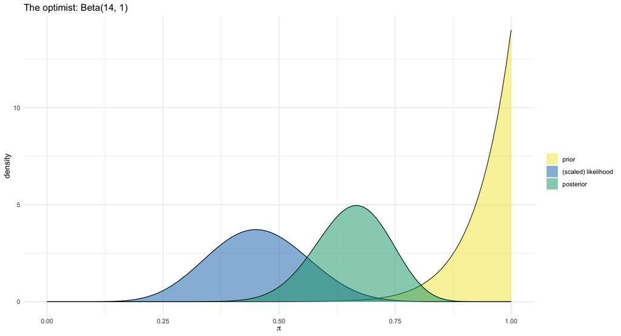

## Example

- In addition to priors affecting our posterior distributions… the data also affects it.
- Let’s now consider three new analysts: they all share the optimistic Beta(14, 1) for $\pi$, however, they have access to different data.
  - Morteza reviews $n = 13$ movies from the year 1991, among which $Y=6$ (about 46%) pass the Bechdel.
  - Nadide reviews $n = 63$ movies from the year 2001, among which $Y=29$ (about 46%) pass the Bechdel.
  - Ursula reviews $n = 99$ movies from the year 2013, among which $Y=46$ (about 46%) pass the Bechdel.
- How will the different data affect the posterior distributions?

## Different Data $\to$ Different Posteriors

- Find the posterior distributions. (i.e., What are the updated parameters?)
  - Recall that all use the Beta(14, 1) prior.

| Analyst | Data | Posterior |
| --- | --- | --- |
| Morteza | $Y=6$ of $n=13$ | Beta(?<sub>1</sub>, ?<sub>2</sub>) |
| Nadide | $Y=29$ of $n=63$ | Beta(?<sub>1</sub>, ?<sub>2</sub>) |
| Ursula | $Y=46$ of $n=99$ | Beta(?<sub>1</sub>, ?<sub>2</sub>) |

## Different Data $\to$ Different Posteriors

- Find the posterior distributions. (i.e., What are the updated parameters?)
  - Recall that all use the Beta(14, 1) prior.

[output not shown]

## Different Data $\to$ Different Posteriors

- Let’s explore what the posteriors look like.

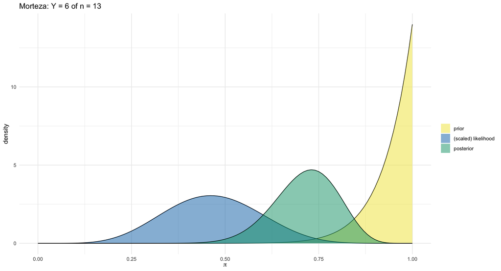

## Different Data $\to$ Different Posteriors

- Let’s explore what the posteriors look like.

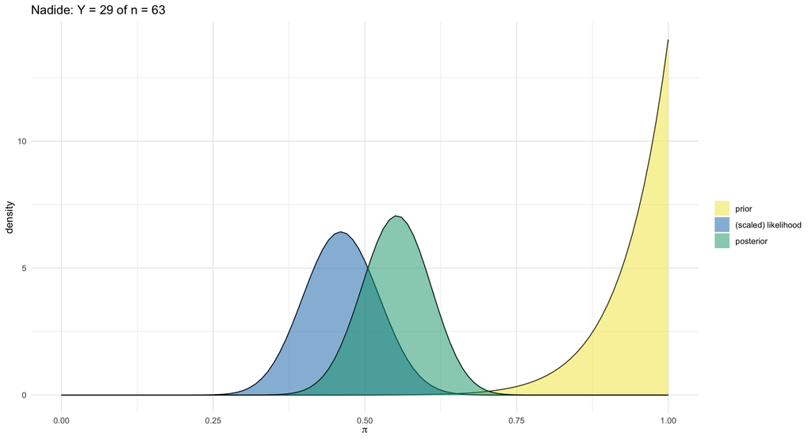

## Different Data $\to$ Different Posteriors

- Let’s explore what the posteriors look like.

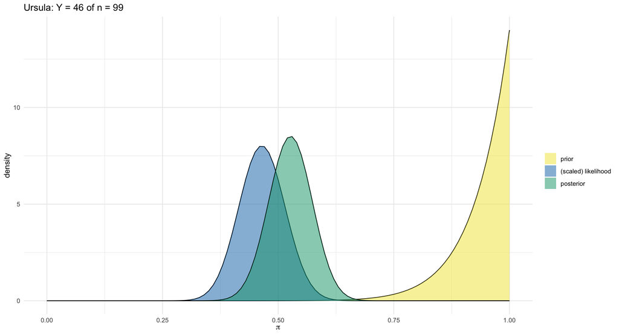

## Different Data $\to$ Different Posteriors

- What did we observe?
  - As $n \to \infty$, variance in the likelihood $\to 0$.
    - In Morteza’s small sample of 13 movies, the likelihood function is wide.
    - In Ursula’s larger sample size of 99 movies, the likelihood function is narrower.
  - We see that the narrower the likelihood, the more influence the data holds over the posterior.

## Striking a Balance

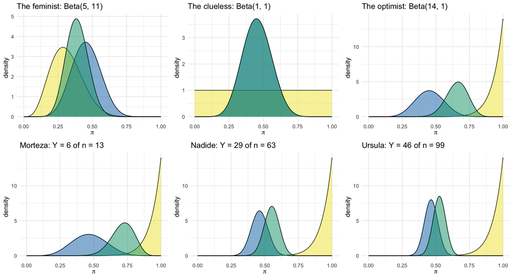

- The posterior can either favor the data or the prior.
  - The rate at which the posterior balance tips in favor of the data depends upon the *prior*.

## Introduction: Sequentiality

- Well, we’ve updated our beliefs… but now we have new data!
- The evolution in our posterior understanding happens *incrementally*, as we accumulate new data.
  - Scientists’ understanding of climate change has evolved over the span of decades as they gain new information.
  - Presidential candidates’ understanding of their chances of winning an election evolve over months as new poll results become available.

## Sequential Bayesian Analysis or Bayesian Learning

- In a sequential Bayesian analysis, a posterior model is updated incrementally as more data come in.
  - With each new piece of data, the previous posterior model reflecting our understanding prior to observing this data becomes the new prior model.
- This is why we love Bayesian!
  - We evolve our thinking as new data come in.
- These types of sequential analyses also uphold two fundamental properties:
  1. The final posterior model is data order invariant,
  2. The final posterior only depends upon the cumulative data.

## Introduction: Example

- In a 1963 issue of *The Journal of Abnormal and Social Psychology*, Stanley Milgram described a study in which he investigated the propensity of people to obey orders from authority figures, even when those orders may harm other people (Milgram 1963).
  - Let $\pi$ represent the proportion of people that will obey authority, even if it means bringing harm to others.
- Prior to Milgram’s experiments, our fictional psychologist expected that few people would obey authority in the face of harming another: $\pi \sim \text{Beta}(1,10)$.

## Introduction: Example

- Now, suppose that the psychologist collected the data incrementally, day by day, over a three-day period.
- Find the following posterior distributions, each building off the last:
  - Day 0: $\text{Beta}(1,10)$.
  - Day 1: $Y=1$ out of $n=10$.
  - Day 2: $Y=17$ out of $n=20$.
  - Day 3: $Y=8$ out of $n=10$.
- Under the Beta-Binomial we know that the posterior is $\text{Beta}(\alpha + y, \beta + n - y)$.
  - Total $y=26$ and $n=40$
  - $\text{Beta}(1,10) \to \text{Beta}(27, 24)$.

## Sequential Bayesian Analysis or Bayesian Learning

- Finding the posterior distributions, each building off the last:
  - Day 0: $\text{Beta}(1,10)$.
  - Day 1: $Y=1$ out of $n=10$: $\text{Beta}(1,10) \to \text{Beta}(2, 19)$.
  - Day 2: $Y=17$ out of $n=20$: $\text{Beta}(2, 19) \to \text{Beta}(19, 22)$.
  - Day 3: $Y=8$ out of $n=10$: $\text{Beta}(19, 22) \to \text{Beta}(27, 24)$.

## Sequential Bayesian Analysis or Bayesian Learning

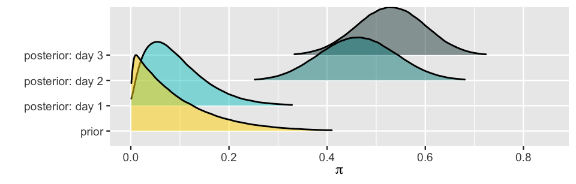

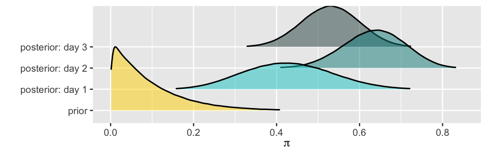

## Tonight: Assignment 6

- See Canvas for link to Google Doc you will edit with your team.
- In Mario Kart 8 Deluxe, mid-pack racers (positions 4-10) were tracked across the Special Cup (Cloudtop Cruise, Bone-Dry Dunes, Bowser’s Castle, and Rainbow Road) because those at the front and end of the pack receive systematically different advantages.
  - **Scenario 1:** Your group is estimating $\pi$, the probability that an item box yields a Red Shell.
  - **Scenario 2:** Your group is modelling $\lambda$, the rate of item boxes opened per minute of race time.
  - **Scenario 3:** Your group is modelling $\mu$, the average race completion time (in seconds).

## Wrap Up

- Today we have discussed balance and sequentiality.
- Remember that order of data inclusion does not matter – we will end up with the same posterior.
- We have seen that prior specification “matters” but there will not be a large difference in the posterior distribution when priors are more similar to one another.
- Next week:
  - Regression!